# EasyVisa Project

## Context:

Business communities in the United States are facing high demand for human resources, but one of the constant challenges is identifying and attracting the right talent, which is perhaps the most important element in remaining competitive. Companies in the United States look for hard-working, talented, and qualified individuals both locally as well as abroad.

The Immigration and Nationality Act (INA) of the US permits foreign workers to come to the United States to work on either a temporary or permanent basis. The act also protects US workers against adverse impacts on their wages or working conditions by ensuring US employers' compliance with statutory requirements when they hire foreign workers to fill workforce shortages. The immigration programs are administered by the Office of Foreign Labor Certification (OFLC).

OFLC processes job certification applications for employers seeking to bring foreign workers into the United States and grants certifications in those cases where employers can demonstrate that there are not sufficient US workers available to perform the work at wages that meet or exceed the wage paid for the occupation in the area of intended employment.

## Objective:

In FY 2016, the OFLC processed 775,979 employer applications for 1,699,957 positions for temporary and permanent labor certifications. This was a nine percent increase in the overall number of processed applications from the previous year. The process of reviewing every case is becoming a tedious task as the number of applicants is increasing every year.

The increasing number of applicants every year calls for a Machine Learning based solution that can help in shortlisting the candidates having higher chances of VISA approval. OFLC has hired your firm EasyVisa for data-driven solutions. You as a data scientist have to analyze the data provided and, with the help of a classification model:

- Facilitate the process of visa approvals.
- Recommend a suitable profile for the applicants for whom the visa should be certified or denied based on the drivers that significantly influence the case status.

## Data Description

The data contains the different attributes of the employee and the employer. The detailed data dictionary is given below.

- case_id: ID of each visa application
- continent: Information of continent the employee
- education_of_employee: Information of education of the employee
- has_job_experience: Does the employee has any job experience? Y= Yes; N = No
- requires_job_training: Does the employee require any job training? Y = Yes; N = No
- no_of_employees: Number of employees in the employer's company
- yr_of_estab: Year in which the employer's company was established
- region_of_employment: Information of foreign worker's intended region of employment in the US.
- prevailing_wage: Average wage paid to similarly employed workers in a specific occupation in the area of intended employment. The purpose of the prevailing wage is to ensure that the foreign worker is not underpaid compared to other workers offering the same or similar service in the same area of employment.
- unit_of_wage: Unit of prevailing wage. Values include Hourly, Weekly, Monthly, and Yearly.
- full_time_position: Is the position of work full-time? Y = Full Time Position; N = Part Time Position
- case_status: Flag indicating if the Visa was certified or denied

## Importing necessary libraries and data

```python
# this will help in making the Python code more structured automatically (good coding practice)
%load_ext nb_black

# Library to suppress warnings or deprecation notes
import warnings

warnings.filterwarnings("ignore")

# Libraries to help with reading and manipulating data
import numpy as np
import pandas as pd

# Libraries to help with data visualization
import matplotlib.pyplot as plt

%matplotlib inline
import seaborn as sns

# Library to split data
from sklearn.model_selection import train_test_split

# Libraries to import decision tree classifier and different ensemble classifiers
from sklearn.ensemble import BaggingClassifier
from sklearn.ensemble import RandomForestClassifier
from sklearn.tree import DecisionTreeClassifier
from sklearn import tree

# Libtune to tune model, get different metric scores
from sklearn import metrics
from sklearn.metrics import (
    confusion_matrix,
    classification_report,
    accuracy_score,
    precision_score,
    recall_score,
    f1_score,
    roc_auc_score,
)
from sklearn.model_selection import GridSearchCV

from sklearn.tree import DecisionTreeClassifier
from sklearn.ensemble import AdaBoostClassifier, GradientBoostingClassifier
from xgboost import XGBClassifier
from sklearn.ensemble import StackingClassifier
```

## Data Overview

### Loading the data

```python
dfeasyvisa = pd.read_csv("EasyVisa.csv")  # loading the data in pandas dataframe
dfeasyvisa_bk = dfeasyvisa.copy()  # creating a backup copy
```

### Head of the data

```python
dfeasyvisa.head()
```

|  | case_id | continent | education_of_employee | has_job_experience | requires_job_training | no_of_employees | yr_of_estab | region_of_employment | prevailing_wage | unit_of_wage | full_time_position | case_status |
| --- | --- | --- | --- | --- | --- | --- | --- | --- | --- | --- | --- | --- |
| 0 | EZYV01 | Asia | High School | N | N | 14513 | 2007 | West | 592.2029 | Hour | Y | Denied |
| 1 | EZYV02 | Asia | Master's | Y | N | 2412 | 2002 | Northeast | 83425.6500 | Year | Y | Certified |
| 2 | EZYV03 | Asia | Bachelor's | N | Y | 44444 | 2008 | West | 122996.8600 | Year | Y | Denied |
| 3 | EZYV04 | Asia | Bachelor's | N | N | 98 | 1897 | West | 83434.0300 | Year | Y | Denied |
| 4 | EZYV05 | Africa | Master's | Y | N | 1082 | 2005 | South | 149907.3900 | Year | Y | Certified |

### Tail of the data

```python
dfeasyvisa.tail()
```

|  | case_id | continent | education_of_employee | has_job_experience | requires_job_training | no_of_employees | yr_of_estab | region_of_employment | prevailing_wage | unit_of_wage | full_time_position | case_status |
| --- | --- | --- | --- | --- | --- | --- | --- | --- | --- | --- | --- | --- |
| 25475 | EZYV25476 | Asia | Bachelor's | Y | Y | 2601 | 2008 | South | 77092.57 | Year | Y | Certified |
| 25476 | EZYV25477 | Asia | High School | Y | N | 3274 | 2006 | Northeast | 279174.79 | Year | Y | Certified |
| 25477 | EZYV25478 | Asia | Master's | Y | N | 1121 | 1910 | South | 146298.85 | Year | N | Certified |
| 25478 | EZYV25479 | Asia | Master's | Y | Y | 1918 | 1887 | West | 86154.77 | Year | Y | Certified |
| 25479 | EZYV25480 | Asia | Bachelor's | Y | N | 3195 | 1960 | Midwest | 70876.91 | Year | Y | Certified |

#### Observations:

- Head and Tail of the data looks clean and as per the data dictionary provided

### Shape of the data

```python
dfeasyvisa.shape
```

```
(25480, 12)
```

#### Observations:

- There are 25480 observations in the dataset provided.
- There are 12 attributes for each observations

### Information on the attributes of the data

```python
dfeasyvisa.info()
```

```
<class 'pandas.core.frame.DataFrame'>
RangeIndex: 25480 entries, 0 to 25479
Data columns (total 12 columns):
 #   Column                 Non-Null Count  Dtype
---  ------                 --------------  -----
 0   case_id                25480 non-null  object
 1   continent              25480 non-null  object
 2   education_of_employee  25480 non-null  object
 3   has_job_experience     25480 non-null  object
 4   requires_job_training  25480 non-null  object
 5   no_of_employees        25480 non-null  int64
 6   yr_of_estab            25480 non-null  int64
 7   region_of_employment   25480 non-null  object
 8   prevailing_wage        25480 non-null  float64
 9   unit_of_wage           25480 non-null  object
 10  full_time_position     25480 non-null  object
 11  case_status            25480 non-null  object
dtypes: float64(1), int64(2), object(9)
memory usage: 2.3+ MB
```

#### Observations:

- We can observe there are 12 columns in this dataset and each column has 25480 non null values, so far we don't see any missing values on the data.
- Except `no_of_employees`, `yr_of_estab` which got loaded as integer, and `prevailing_wage` which got loaded as float, all other columns are text type and loaded as object.

### Check for missing values

```python
dfeasyvisa.isnull().sum()
```

```
case_id                  0
continent                0
education_of_employee    0
has_job_experience       0
requires_job_training    0
no_of_employees          0
yr_of_estab              0
region_of_employment     0
prevailing_wage          0
unit_of_wage             0
full_time_position       0
case_status              0
dtype: int64
```

#### Observations:

- This confirms our understanding there are no missing values in the dataset

### Check for duplicate rows

```python
dfeasyvisa.duplicated().sum()
```

```
0
```

#### Observations:

- We can see there are no duplicate rows in the dataset

## Exploratory Data Analysis (EDA)

**Key Questions we will be answering as part of our EDA**:

1. Does education play a role in Visa certification?
2. How does the visa status vary across different continents?
3. Does work experience influence visa status?
4. Which pay unit is most likely to be certified for a visa?
5. How does the visa status change with the prevailing wage?

### Check the summary of the data

#### Numerical Columns

```python
dfeasyvisa.describe().T  # summary of numeric columns, transpose for better readability
```

|  | count | mean | std | min | 25% | 50% | 75% | max |
| --- | --- | --- | --- | --- | --- | --- | --- | --- |
| no_of_employees | 25480.0 | 5667.043210 | 22877.928848 | -26.0000 | 1022.00 | 2109.00 | 3504.0000 | 602069.00 |
| yr_of_estab | 25480.0 | 1979.409929 | 42.366929 | 1800.0000 | 1976.00 | 1997.00 | 2005.0000 | 2016.00 |
| prevailing_wage | 25480.0 | 74455.814592 | 52815.942327 | 2.1367 | 34015.48 | 70308.21 | 107735.5125 | 319210.27 |

#### Observations:

- `no_of_employees` data ranging from -26 to 602069 with mean as ~5667. 75% of the data are within ~3500. Min value of no of employees as -26 seems not correct, we shall see how to treat this during data preparation
- `yr_of_estab` shows we have data for companies established from 1800 to 2016, where 75% of the companies are established by year 2005
- `prevailing_wage` for the similarly employed workers in a specific role and region ranges from ~2.13 to ~319210.27. Min value of prevailing wage looks very low we shall see based on the unit as because of unit difference this could be a low value.

#### Categorical Columns

```python
dfeasyvisa.describe(include="object").T  # summary for object columns
```

|  | count | unique | top | freq |
| --- | --- | --- | --- | --- |
| case_id | 25480 | 25480 | EZYV01 | 1 |
| continent | 25480 | 6 | Asia | 16861 |
| education_of_employee | 25480 | 4 | Bachelor's | 10234 |
| has_job_experience | 25480 | 2 | Y | 14802 |
| requires_job_training | 25480 | 2 | N | 22525 |
| region_of_employment | 25480 | 5 | Northeast | 7195 |
| unit_of_wage | 25480 | 4 | Year | 22962 |
| full_time_position | 25480 | 2 | Y | 22773 |
| case_status | 25480 | 2 | Certified | 17018 |

#### Observations:

- `case_id` This is a unique number for each applicants, this will not have any statistical significance, hence will be dropped prior to model creation
- `continent` We can observe the data of applicants are from 6 different continents and Asia has the most 16861 applicants.
- `education_of_employee` Applicants have 4 unique type of education, Most applicants (10234) have completed Bachelors
- `has_job_experience` Majority of applicants have job experience, total 14802.
- `requires_job_training` 22525 applicants doesn't need job training, which means only ~3000 applicants require job training
- `region_of_employment` There are 5 unique region of employements where the applicants have applied their VISA for, Northeast has highest employment visa applicants
- `unit_of_wage` There are 4 different units of prevailing wage present in the data, Year has the highest counts and almost all of data.
- `full_time_position` Among 25480 applicants, 22773 are for full time position.
- `case_status` Majority of the applicants have their visa approved. 17018 out of 25480 shows as certified.

### Before we proceed further, changing the object type columns to Categorical

```python
for col in dfeasyvisa.select_dtypes("object").columns:
    dfeasyvisa[col] = dfeasyvisa[col].astype("category")
dfeasyvisa.info()
```

```
<class 'pandas.core.frame.DataFrame'>
RangeIndex: 25480 entries, 0 to 25479
Data columns (total 12 columns):
 #   Column                 Non-Null Count  Dtype
---  ------                 --------------  -----
 0   case_id                25480 non-null  category
 1   continent              25480 non-null  category
 2   education_of_employee  25480 non-null  category
 3   has_job_experience     25480 non-null  category
 4   requires_job_training  25480 non-null  category
 5   no_of_employees        25480 non-null  int64
 6   yr_of_estab            25480 non-null  int64
 7   region_of_employment   25480 non-null  category
 8   prevailing_wage        25480 non-null  float64
 9   unit_of_wage           25480 non-null  category
 10  full_time_position     25480 non-null  category
 11  case_status            25480 non-null  category
dtypes: category(9), float64(1), int64(2)
memory usage: 2.0 MB
```

#### Observations:

- We can see all the object type columns are converted to categorical type columns

### Unique values in categorical columns

```python
cat_cols = dfeasyvisa.select_dtypes("category").columns
for col in cat_cols:
    print("Unique values in", col, "are :")
    print(dfeasyvisa[col].value_counts())
    print("*" * 50)
```

```
Unique values in case_id are :
EZYV01       1
EZYV25287    1
EZYV25285    1
EZYV25284    1
EZYV25283    1
            ..
EZYV17633    1
EZYV17632    1
EZYV17631    1
EZYV17630    1
EZYV9999     1
Name: case_id, Length: 25480, dtype: int64
Unique values in continent are :
Asia             16861
Europe            3732
North America     3292
South America      852
Africa             551
Oceania            192
Name: continent, dtype: int64
Unique values in education_of_employee are :
Bachelor's     10234
Master's        9634
High School     3420
Doctorate       2192
Name: education_of_employee, dtype: int64
Unique values in has_job_experience are :
Y    14802
N    10678
Name: has_job_experience, dtype: int64
Unique values in requires_job_training are :
N    22525
Y     2955
Name: requires_job_training, dtype: int64
Unique values in region_of_employment are :
Northeast    7195
South        7017
West         6586
Midwest      4307
Island        375
Name: region_of_employment, dtype: int64
Unique values in unit_of_wage are :
Year     22962
Hour      2157
Week       272
Month       89
Name: unit_of_wage, dtype: int64
Unique values in full_time_position are :
Y    22773
N     2707
Name: full_time_position, dtype: int64
Unique values in case_status are :
Certified    17018
Denied        8462
Name: case_status, dtype: int64
```

#### Observations:

- The no# of unique values are what we have observed from the summary of the data.
- We can see there are some unique values which has spaces in between or special characters, we will replace them in data preprocessing

## Univariate Analysis

### Let's create the functions first which will generate the required plots

```python
# Below is a function which will take input as numerical attributes,
# titlevar to be able to dynamically populate the title for each plot
# figure size (to have the flexibility to have custom figsize if necessary), bins(for histogram) and
# returns boxplot and histogram plot for the numerical attribute passed.
def box_hist(feature, titlevar, figsize=(15, 10), bins=None):
    sns.set(style="ticks")
    sns.set_style("darkgrid")
    fig, (axb, axh) = plt.subplots(
        nrows=2,  # Number of rows to be plotted for subplot
        sharex=True,  # x-axis will be shared for all subplots
        gridspec_kw={
            "height_ratios": (0.25, 0.75)
        },  # pass on the grid spaces to Gridspace constructor for subplots
        figsize=figsize,
    )
    sns.boxplot(
        feature,
        ax=axb,
        showmeans=True,
        color="#00FFA0",
        meanprops={"markerfacecolor": "white", "markeredgecolor": "black"},
    )  # plots the boxplot and show a marker for mean value
    axb.set_title("BoxPlot for: {}".format(titlevar), fontweight="bold", fontsize=18)
    sns.distplot(
        feature, ax=axh, kde=True, bins=bins, color="#004DFD"
    ) if bins else sns.distplot(
        feature, ax=axh, kde=True, color="#004DFD"
    )  # plots histogram
    axh.axvline(
        np.mean(feature), linestyle="-", color="red"
    )  # Add a red vertical line for mean value of the feature
    axh.axvline(
        np.median(feature), linestyle="--", color="black"
    )  # Add a green vertical line for median value of the feature
    plt.ylabel("Count")
    axh.set_title(
        "Distribution Plot for: {}".format(titlevar), fontweight="bold", fontsize=18
    )
```

```python
# function to create labeled barplots


def labeled_barplot(data, feature, perc=False, n=None):
    """
    Barplot with percentage at the top

    data: dataframe
    feature: dataframe column
    perc: whether to display percentages instead of count (default is False)
    n: displays the top n category levels (default is None, i.e., display all levels)
    """
    sns.set(style="ticks")
    sns.set_style("darkgrid")
    total = len(data[feature])  # length of the column
    count = data[feature].nunique()
    plt.figure(figsize=(15, 10))
    plt.xticks(rotation=90, fontsize=15)
    ax = sns.countplot(
        data=data,
        x=feature,
        palette="Paired",
        order=data[feature].value_counts().index[:n].sort_values(),
    )
    ax.set_title(
        "Proportion of Visa applicants based on: {}".format(feature),
        fontweight="bold",
        fontsize=14,
    )
    for p in ax.patches:
        if perc == True:
            label = "{:.1f}%".format(
                100 * p.get_height() / total
            )  # percentage of each class of the category
        else:
            label = p.get_height()  # count of each level of the category

        x = p.get_x() + p.get_width() / 2  # width of the plot
        y = p.get_height()  # height of the plot

        ax.annotate(
            label,
            (x, y),
            ha="center",
            va="center",
            size=12,
            xytext=(0, 5),
            textcoords="offset points",
        )  # annotate the percentage

    plt.show()  # show the plot
```

### Exploring no_of_employees

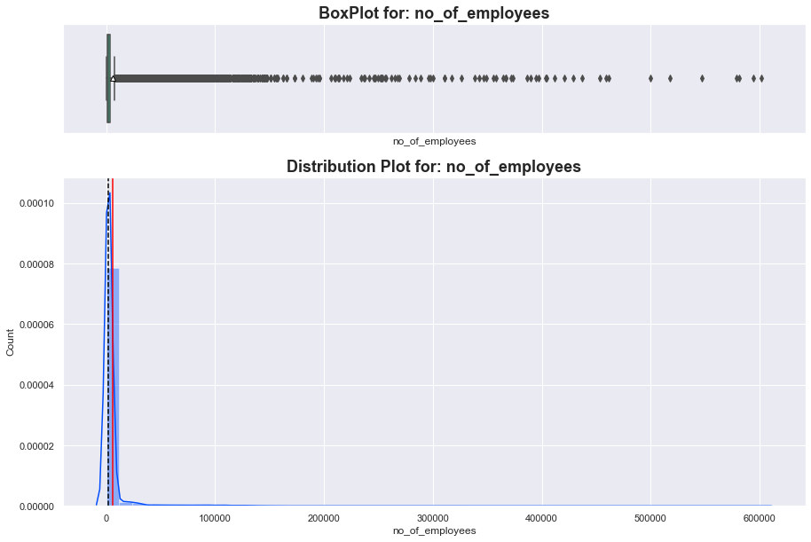

```python
box_hist(dfeasyvisa["no_of_employees"], "no_of_employees")
```

#### Observations:

- The data is heavily right skewed with majority of the employers having ~3500 (observed earlier in summary) employees.
- There are employers which has higher number of employees, we can see it goes as high as 600000 employees.
- There are employers with employee count as negative.
- From boxplot we can observe there are lot of outliers, we may have to derive new feature and see if that will have any influence on visa status

### Exploring prevailing_wage

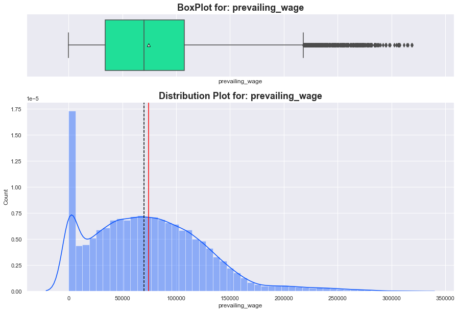

```python
box_hist(dfeasyvisa["prevailing_wage"], "prevailing_wage")
```

#### Observations:

- We can see the data is slightly right skewed and have outliers on the higher side.
- The prevailing wage goes as high as > 300000
- We can see a peak in prevaling wage ~5000 which has higher number of observations
- As we know data in this column has different units present in unit_of_wage column, we shall revisit this variable after bringing all prevailing wage into a single unit and see if that also shows the peak we observed.

### Exploring yr_of_estab

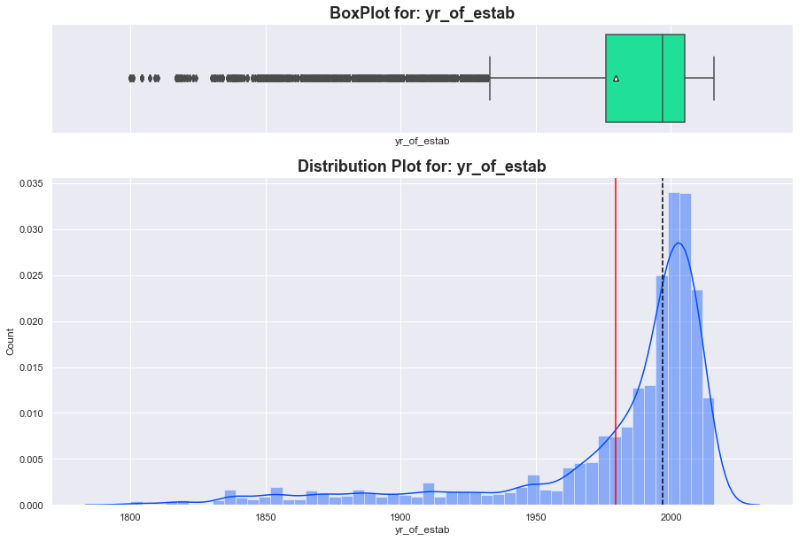

```python
box_hist(dfeasyvisa["yr_of_estab"], "yr_of_estab")
```

#### Observations:

- We can observe the data is heavily left skewed, with employers established as old as year ~1800
- Majority of the applicants are from employers who are established on or after ~1975

#### Let's also check the counts of visa applicants by year

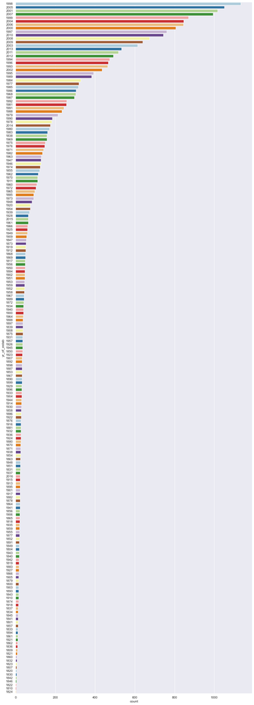

```python
fig, ax = plt.subplots(figsize=(15, 45))  # figsize and axis declaration
sns.set_style("darkgrid")  # seaborn background set to dark
ax = sns.countplot(
    y="yr_of_estab",
    data=dfeasyvisa,
    orient="v",
    palette="Paired",
    order=dfeasyvisa["yr_of_estab"].value_counts().index,
)  # plotting the countplot
plt.show()
```

#### Observations:

- Top 10 employers in terms of most no of visa applicants are all established on or after 1997.
- Employers established in 1998 shows the highest number of visa applicants

### Exploring variable continent

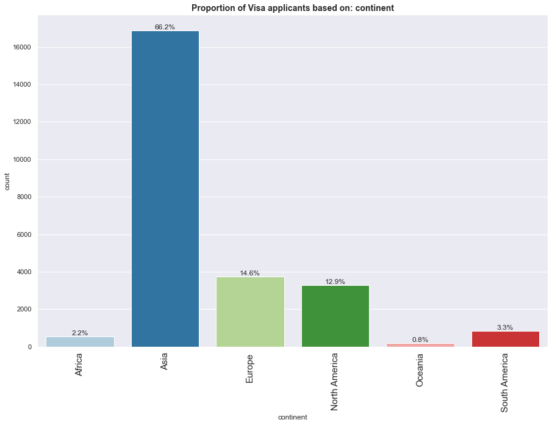

```python
labeled_barplot(dfeasyvisa, "continent", perc=True)
```

#### Observations:

- We can observe among 6 continents Asia shows the highest number of applicants ~66.2%
- Oceania is the lowest for visa applicatns with only .8%

### Exploring variable education_of_employee

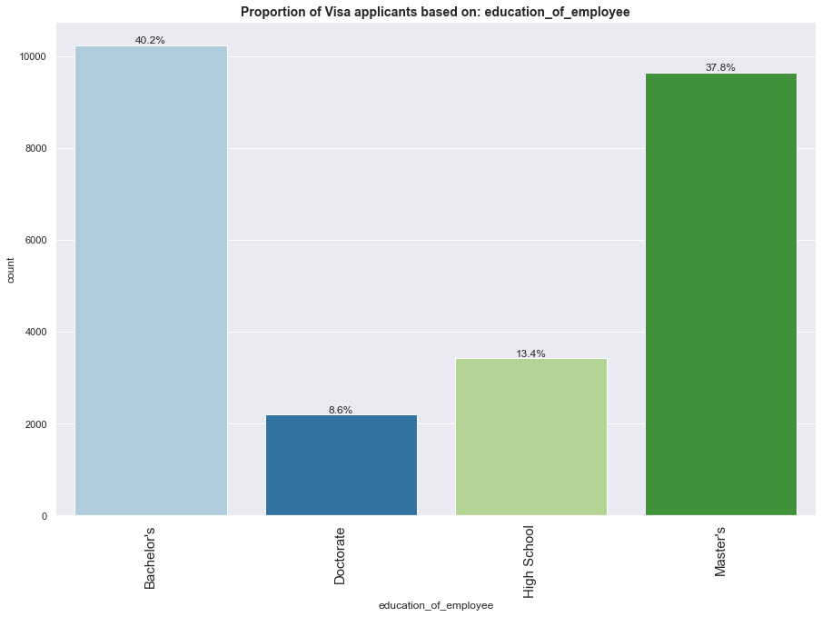

```python
labeled_barplot(dfeasyvisa, "education_of_employee", perc=True)
```

#### Observations:

- We can see there are 4 unique level of educations for the applicants.
- ~78% of visa applicants have Bachelor's and Master's degree, with 40.2% in Bachelor's and 37.8% in Masters
- Doctorate degree holders are the lowest among visa applicants, ~8.6%
- ~13% of Visa applicants are only high school pass outs.

### Exploring the variable has_job_experience

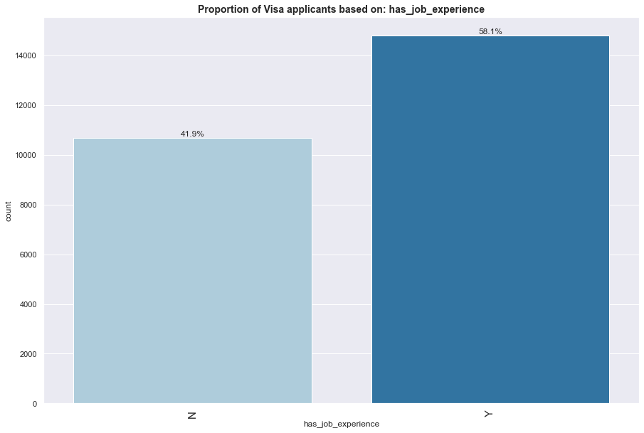

```python
labeled_barplot(dfeasyvisa, "has_job_experience", perc=True)
```

#### Observations:

- ~58% of visa applicatns are having prior job experience, this can confirm our general understanding for work visas.
- ~42% of visa applicants are not having any prior job experience.

### Exploring the variable requires_job_training

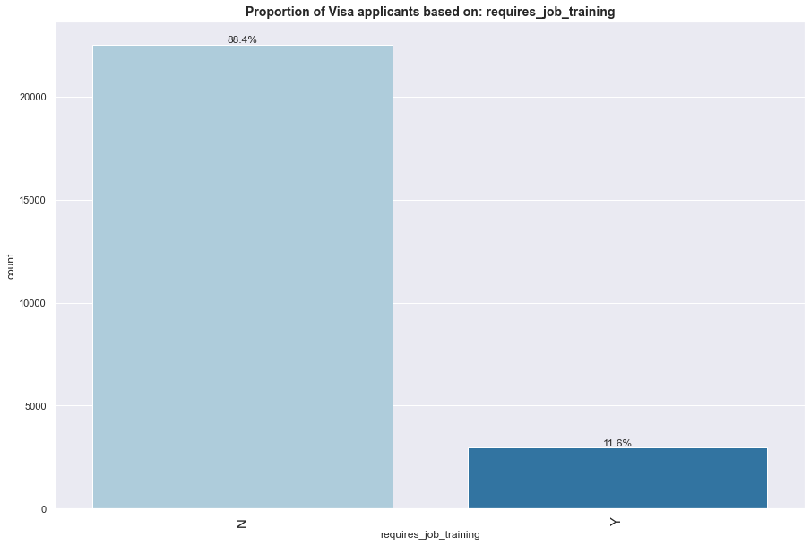

```python
labeled_barplot(dfeasyvisa, "requires_job_training", perc=True)
```

#### Observations:

- ~88% of visa applicants doesn't require job training, this goes with the idea of applicants have prior job experience.
- ~12% of applicants would require job training.

### Exploring the variable region_of_employment

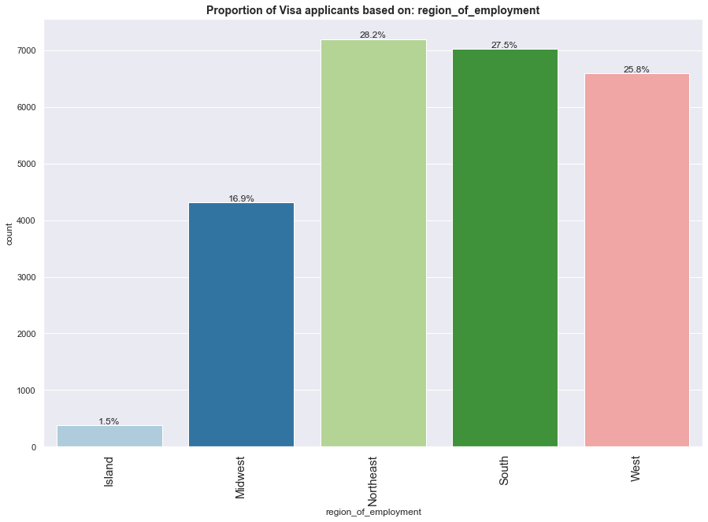

```python
labeled_barplot(dfeasyvisa, "region_of_employment", perc=True)
```

#### Observations:

- With ~28% visa applicants Northeast is the highest intended work region of US.
- South and West also has similar proportion of visa applicants, 27.5%, 25.8% respectively.
- Island of US has the lowest number of visa applicants, only 1.5%
- Midwest shows decent number of applicants as well, ~16.9%

### Exploring the variable unit_of_wage

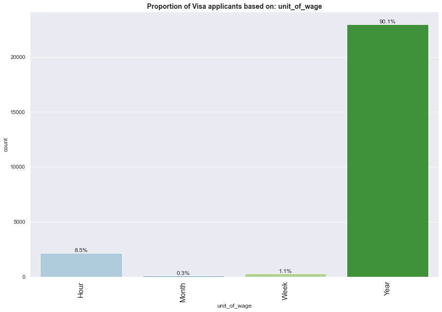

```python
labeled_barplot(dfeasyvisa, "unit_of_wage", perc=True)
```

#### Observations:

- There are 4 different units of prevailing wages present in the dataset.
- Yearly wages are most common and confirms our general understanding, it's ~90% of the data.
- Hourly, Monthly, and weekly wages are mentioned for 8.5%, 0.3%, 1.1% of visa applicants

### Exploring the variable full_time_position

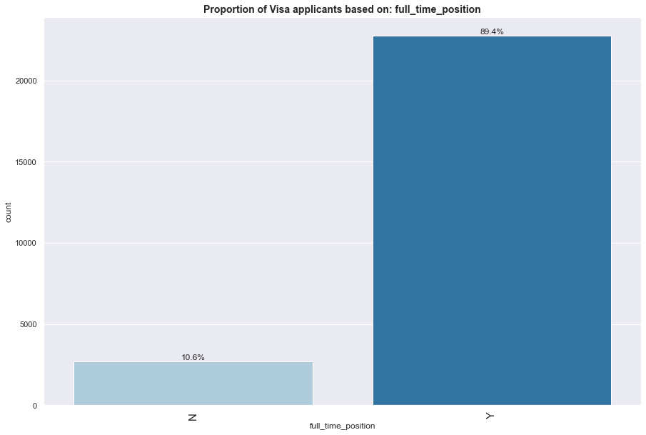

```python
labeled_barplot(dfeasyvisa, "full_time_position", perc=True)
```

#### Observations:

- ~89% of the visa applicants are for full time positions
- ~11% are for temporary positions or other contractual positions

### Exploring the variable case_status

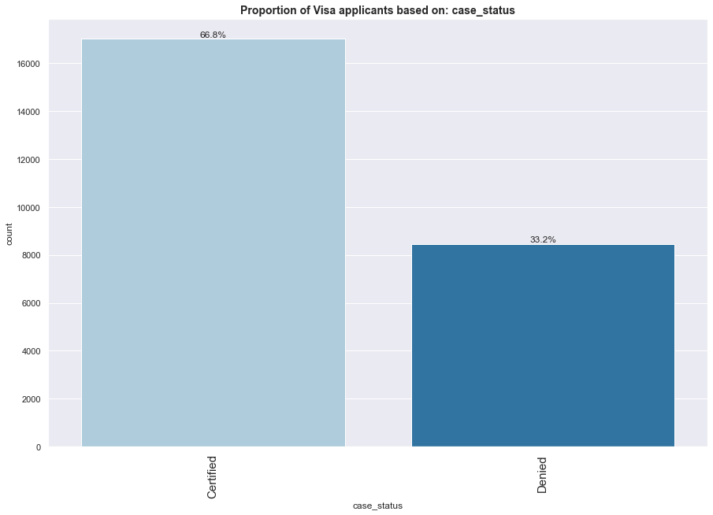

```python
labeled_barplot(dfeasyvisa, "case_status", perc=True)
```

#### Observations:

- This is our target variable and has 2 unique category, Certified and Denied.
- We can observe ~67% of applicants visas are certified/approved.
- 33% of visas are denied.

## Bivariate Analysis

### As we have many categorical variables, let's write a function for stacked barplot

```python
# function to plot stacked bar chart


def stacked_barplot(data, predictor, target):
    """
    Print the category counts and plot a stacked bar chart

    data: dataframe
    predictor: independent variable
    target: target variable
    """
    sns.set(style="ticks")
    # sns.set_style("darkgrid")
    count = data[predictor].nunique()
    sorter = data[target].value_counts().index[-1]
    # tab1 = pd.crosstab(data[predictor], data[target], margins=True).sort_values(
    #    by=sorter, ascending=False
    # )
    # print(tab1)
    # print("-" * 100)
    tab = pd.crosstab(data[predictor], data[target], normalize="index").sort_values(
        by=sorter, ascending=False
    )
    ax = tab.plot(
        kind="bar", stacked=True, figsize=(15, 8), color=["Lightgreen", "lightblue"]
    )
    plt.legend(
        loc="lower left", frameon=False,
    )
    plt.legend(loc="upper left", bbox_to_anchor=(1, 1))
    plt.ylabel("Proportion", fontsize=12)
    plt.xlabel(f"{predictor} wise {target}", fontsize=12)
    plt.title(
        f"Proportion of {target} in {predictor}", fontsize=16, fontweight="bold",
    )
    # Below loop will annotate the bar patches with it's respective percentages
    for p in ax.patches:
        height = p.get_height()
        x = p.get_x() + p.get_width() / 2
        y = p.get_y() + height / 2
        ax.text(
            x,
            y,
            "{:.1f} %".format(height * 100),
            horizontalalignment="center",
            verticalalignment="center",
        )
    plt.show()
```

### Checking Continent wise Case status

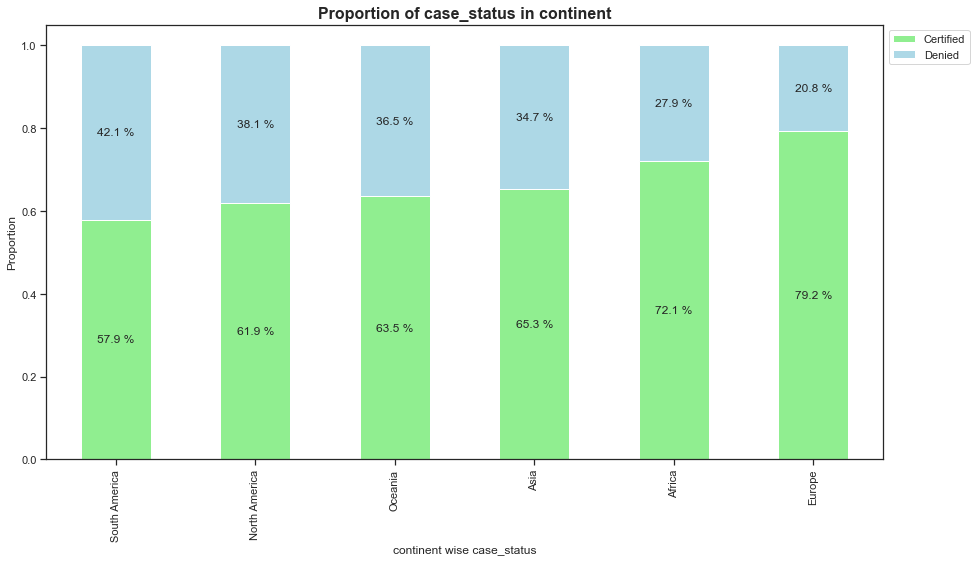

```python
stacked_barplot(dfeasyvisa, "continent", "case_status")
```

#### Observations:

- Europe has the highest visa certified rate, close to ~79% of europe applicants have their visa certified, ~21% got rejected
- Africa has the second highest approval rate - ~72%
- South America shows the lowest approval rate with ~58%
- Asia, Oceania, North America all has their approval rate ranging ~62% to ~65%

**Key Question - How does the visa status vary across different continents?**

- We observed based on the applicatn's continets the visa status does vary

### Checking Education of employee vs Case Status

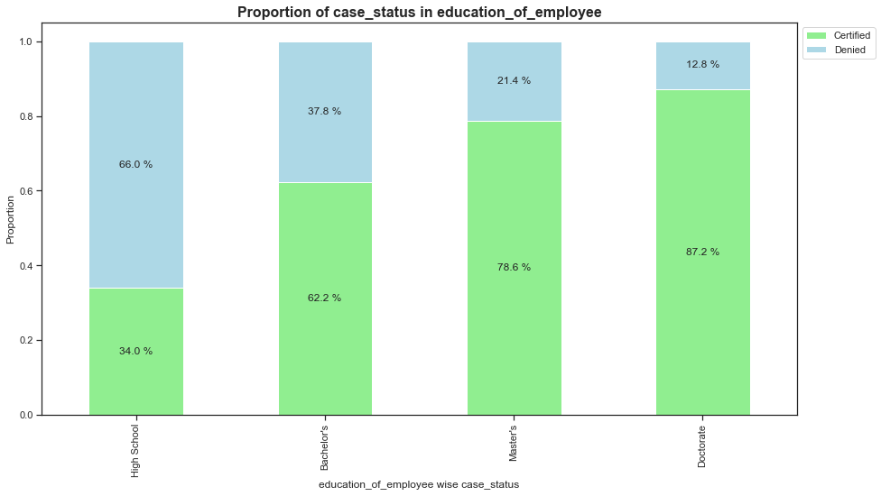

```python
stacked_barplot(dfeasyvisa, "education_of_employee", "case_status")
```

#### Observations:

- There is a obvious segration in approval odds based on employee's education. The higher the education, the odds of get their visa certified increases.
- The highest form of degree present in data is Doctorate, which has close to ~87% approval rate.
- Holding Master's degree has ~79% approval rate, and Bachelor's degree have ~62%.
- Only high school passouts have the lowest approval rate 34%

**Key Question - Does education play a role in Visa certification?**

- The answer is is based on the observations we can say the higher the employee's education more likely to get his/her visa certified/approved

### Checking Job Experience vs Case Status

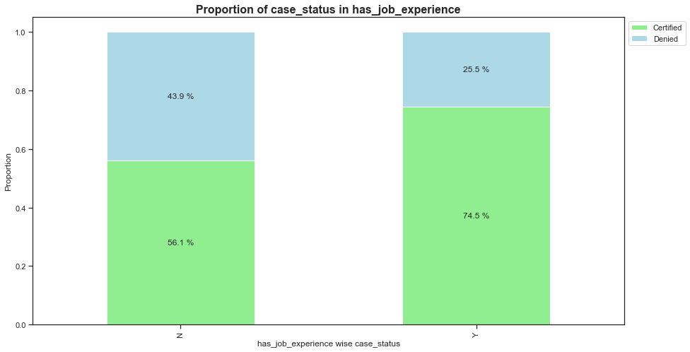

```python
stacked_barplot(dfeasyvisa, "has_job_experience", "case_status")
```

#### Observations:

- Employees who has job experience are more likely to get their visa certified. We can see ~75% of visas are approved for employees who has job experience.
- ~56% of visa gets approved for employees with no job experience.

**Key Question - Does work experience influence visa status?**

- We observed that having job experience certainly increase the chances of visa getting certified

### Checking Requires_job_training vs Case Status

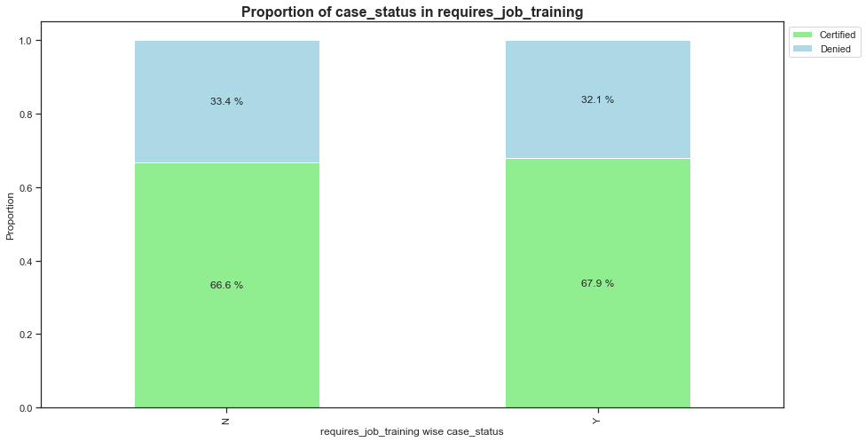

```python
stacked_barplot(dfeasyvisa, "requires_job_training", "case_status")
```

#### Observations:

- We can see there's not much difference in approval rate difference based on employee's require job training or not.
- In both cases approval rate is ~67%-68%

### Checking Region_of_employment vs Case status

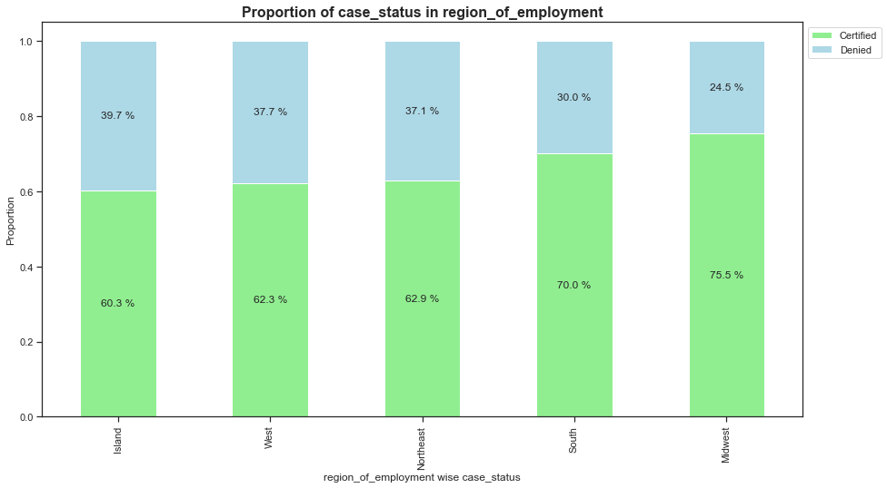

```python
stacked_barplot(dfeasyvisa, "region_of_employment", "case_status")
```

#### Observations:

- Intended employment region South and Midwest shows higher approval rate ~70%, ~76% respectively
- All other intended employment region shows approval rate close to ~60% to ~62%

### Checking Unit_of_wage vs Case Status

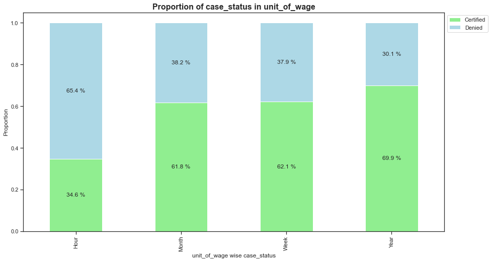

```python
stacked_barplot(dfeasyvisa, "unit_of_wage", "case_status")
```

#### Observations:

- We can observe Yearly, Weekly, Monthly has almost similar approval rate ranging from ~62% to 70%, Yearly being the highest with ~70% approval rate.
- Hourly prevaling wages shows the lowest approval rate ~35%

**Key Question - Which pay unit is most likely to be certified for a visa?**

- We can observe if the employee wage is yearly then the chances of getting VISA certified is the highest

### Checking Full_time_position vs Case Status

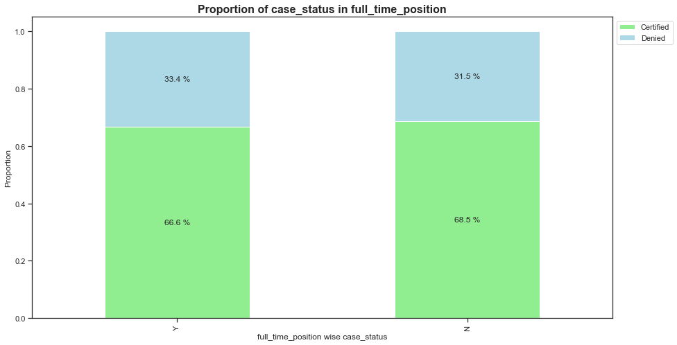

```python
stacked_barplot(dfeasyvisa, "full_time_position", "case_status")
```

#### Observations:

- We don't see there's much difference in the approval rate if the position applicant is applying for is a full time or not.
- Both cases shows approval rate almost similar ~67% and ~68%

### Checking the No_of_employees vs Case status

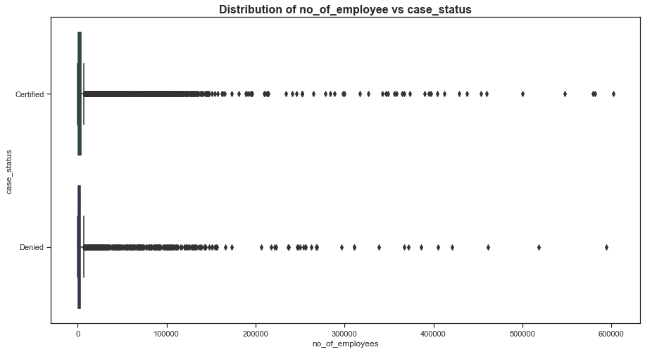

```python
# plots boxplots for no of employees for each case status
fig, ax = plt.subplots(figsize=(15, 8))
ax = sns.boxplot(
    dfeasyvisa["no_of_employees"],
    dfeasyvisa["case_status"],
    orient="h",
    palette="winter_r",
)
plt.title(
    "Distribution of no_of_employee vs case_status", fontsize=16, fontweight="bold"
)
plt.show()
```

#### Observations:

- We can see there is no difference in the distribution of no_of_employees for both the case status
- Case status shows no relationship with no of employees variable

### Checking yr_of_estab vs case_status

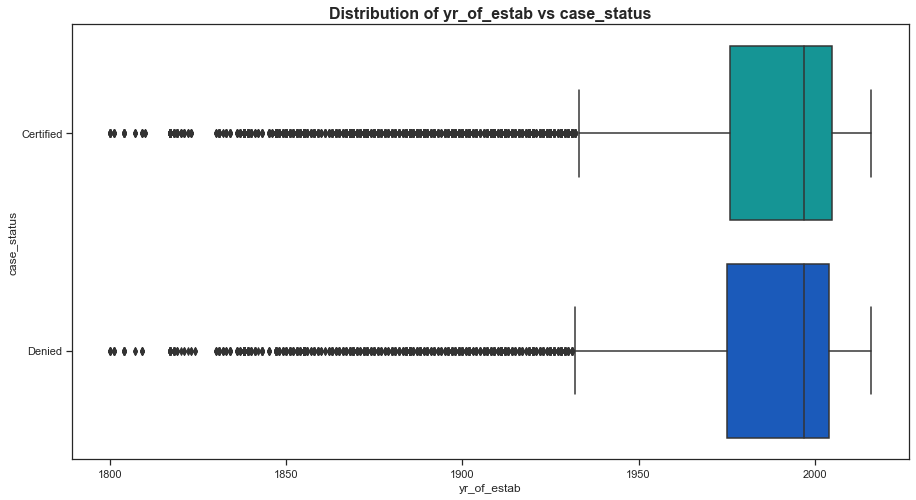

```python
# plots boxplots for year of establish for employers for each case status
fig, ax = plt.subplots(figsize=(15, 8))
ax = sns.boxplot(
    dfeasyvisa["yr_of_estab"], dfeasyvisa["case_status"], orient="h", palette="winter_r"
)
plt.title("Distribution of yr_of_estab vs case_status", fontsize=16, fontweight="bold")
plt.show()
```

#### Observations:

- Year of establishment doesn't show any relation with case status.
- Data distribution and mean both are samilar for both case status.

### Checking prevailing_wage vs case_status

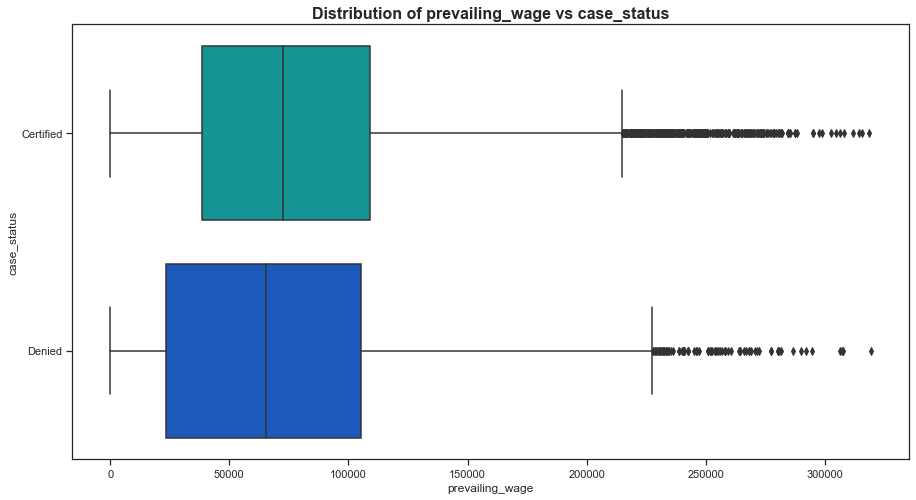

```python
# plots boxplots for prevailing wage for each case status
fig, ax = plt.subplots(figsize=(15, 8))
ax = sns.boxplot(
    dfeasyvisa["prevailing_wage"],
    dfeasyvisa["case_status"],
    orient="h",
    palette="winter_r",
)
plt.title(
    "Distribution of prevailing_wage vs case_status", fontsize=16, fontweight="bold"
)
plt.show()
```

#### Observations:

- We can observe with higher prevailing wage chances of visa being certified increases.
- Average prevailing wage is higher for the cases which are certified than those which are denied.

**Key question - How does the visa status change with the prevailing wage?**

- We can observe the higher average prevailing wage will have more chances of VISA being granted

## Data Preprocessing

- Missing value treatment - We do not have any missing values for the data set, hence not needed.
- Let's do the other preprocessing step

### Removing spaces from continent variable values

```python
dfeasyvisa["continent"] = dfeasyvisa["continent"].str.replace(
    " ", ""
)  # removing whitespace from continet variable values
dfeasyvisa["continent"].value_counts()
```

```
Asia            16861
Europe           3732
NorthAmerica     3292
SouthAmerica      852
Africa            551
Oceania           192
Name: continent, dtype: int64
```

#### Observations:

- We can see we have succesfully removed the whitespace which was present for North and South america values

### Removing special character from the education of employee variable values

```python
dfeasyvisa["education_of_employee"] = dfeasyvisa["education_of_employee"].str.replace(
    "'", ""
)  # removing special character from education variable values
dfeasyvisa["education_of_employee"].value_counts()
```

```
Bachelors      10234
Masters         9634
High School     3420
Doctorate       2192
Name: education_of_employee, dtype: int64
```

#### Observations:

- We can see we have succesfully removed the "'" special character which was present in the values

### Remove spaces from education of employee variable value

```python
dfeasyvisa["education_of_employee"] = dfeasyvisa["education_of_employee"].str.replace(
    " ", ""
)  # removing special character from education variable values
dfeasyvisa["education_of_employee"].value_counts()
```

```
Bachelors     10234
Masters        9634
HighSchool     3420
Doctorate      2192
Name: education_of_employee, dtype: int64
```

#### Observations:

- All the unique values doesn't have any special characters in it

### Feature Engineering

- We have noticed the data in `no_of_employees` variable is very skewed and the 75% of the data are within ~3500. We have also observed that this variable doesn't show any noticeable influence of the case status our dependent variable. We will try to bin the no of employees and create a feature which will only tell us the size of the company in terms of employee strength
- We have observed `prevailing_wage` variable is not in same unit. We could try converting and bring all values into same unit, but in clarification Academic team suggested not to do. We will bin the data and create new feature wage group.

#### Creating new feature employer_size

```python
#Creating a new variable using the no of employees column based on value range. We are using numpy's np.where
dfeasyvisa['employer_size'] = ' '
dfeasyvisa['employer_size'] = np.where((dfeasyvisa['no_of_employees'] < 1101), 'Small',dfeasyvisa['employer_size'])
dfeasyvisa['employer_size'] = np.where((dfeasyvisa['no_of_employees'] >= 1101) & (dfeasyvisa['no_of_employees'] < 2201) , 'Medium',dfeasyvisa['employer_size'])
dfeasyvisa['employer_size'] = np.where((dfeasyvisa['no_of_employees'] >= 2201) & (dfeasyvisa['no_of_employees'] < 3601) , 'Large',dfeasyvisa['employer_size'])
dfeasyvisa['employer_size'] = np.where((dfeasyvisa['no_of_employees'] >= 3601), 'VeryLarge',dfeasyvisa['employer_size'])
dfeasyvisa['employer_size'].value_counts()
```

```
Small        6843
Medium       6372
Large        6229
VeryLarge    6036
Name: employer_size, dtype: int64
```

#### Observations:

- We have succesfully created the new feature `employer_size` based on no of employees
- The data proportions in each unique values looks smilar based on the value range chosen using the 5 point summary of no of employees variable

#### Creating new feature prevailing_wage_group

```python
# Creating a new variable using the prevailing wage based on value range. We are using numpy's np.where
dfeasyvisa["prevailing_wage_group"] = " "
dfeasyvisa["prevailing_wage_group"] = np.where(
    (dfeasyvisa["prevailing_wage"] < 35001), "Low", dfeasyvisa["prevailing_wage_group"]
)
dfeasyvisa["prevailing_wage_group"] = np.where(
    (dfeasyvisa["prevailing_wage"] >= 35001) & (dfeasyvisa["prevailing_wage"] < 75001),
    "Average",
    dfeasyvisa["prevailing_wage_group"],
)
dfeasyvisa["prevailing_wage_group"] = np.where(
    (dfeasyvisa["prevailing_wage"] >= 75001),
    "High",
    dfeasyvisa["prevailing_wage_group"],
)
dfeasyvisa["prevailing_wage_group"].value_counts()
```

```
High       11891
Average     7064
Low         6525
Name: prevailing_wage_group, dtype: int64
```

#### Observations:

- We have created the new feature `prevailing_wage_group` with 3 unique category
- The data proportions in each unique values looks decent based on the value range chosen using 5 points summary of prevailing wage variable

### Outliers detection

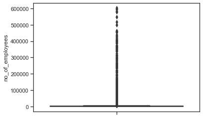

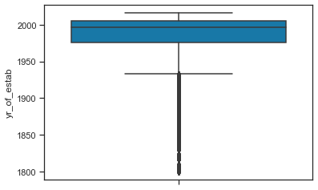

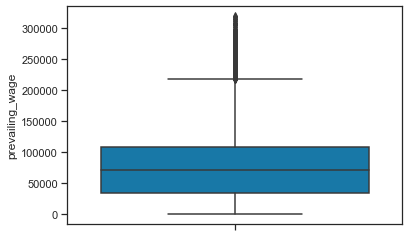

```python
num_cols = dfeasyvisa.select_dtypes(["int", "float"]).columns
for col in num_cols:
    ax = sns.boxplot(y=dfeasyvisa[col], orient="v", whis=1.5, palette="winter")
    plt.show()
```

#### Observations:

- `no_of_employees` and `yr_of_estab` both are discreet in nature and we will not treat outliers for these features.
- `prevailing_wage` shows outliers but data in this variable has data from multiple units, and not enough information to convert them into same unit, also we have derived a new feature out of it, so we are not going to treat the outliers in this variable

### Identifying negative values

```python
# checking negative value count in no of employees
dfeasyvisa[dfeasyvisa["no_of_employees"] < 0]["case_id"].count()
```

```
33
```

```python
# checking negative value count in prevailing wage
dfeasyvisa[dfeasyvisa["prevailing_wage"] < 0]["case_id"].count()
```

```
0
```

```python
# checking negative value count in year of establishment
dfeasyvisa[dfeasyvisa["yr_of_estab"] < 0]["case_id"].count()
```

```
0
```

#### Observations:

- We can observe we have 33 negative values in `no_of_employees` variable, as we know a company cannot have employees in negative, upon clarification it was suggested to take absolute values of them.

### Converting negative values of no_of_employees variable

```python
dfeasyvisa["no_of_employees"] = dfeasyvisa["no_of_employees"].abs()
# checking negative value count in no of employees
dfeasyvisa[dfeasyvisa["no_of_employees"] < 0]["case_id"].count()
```

```
0
```

#### Observations:

- We can see we have succesfully removed the negative values from this feature

## EDA Contd..

### Checking the new feature employer_size vs case_status

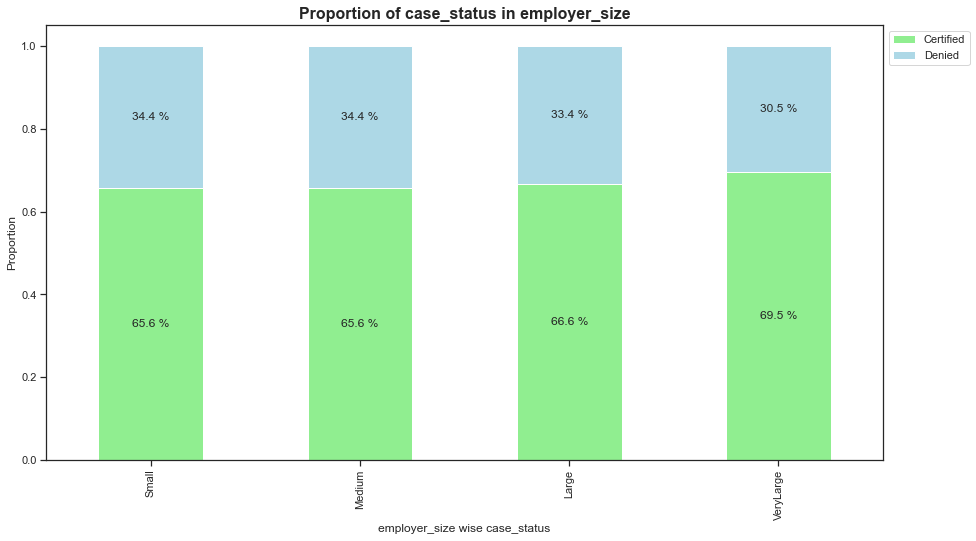

```python
stacked_barplot(dfeasyvisa, "employer_size", "case_status")
```

#### Observations:

- Except VeryLarge employers all other employers shows same approvals and rejection rates.
- For VeryLarge employers approvals rate is close to ~70%

### Checking the new feature prevailing_wage_group vs case_status

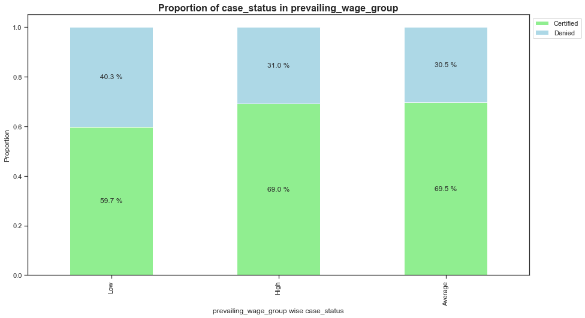

```python
stacked_barplot(dfeasyvisa, "prevailing_wage_group", "case_status")
```

#### Observations:

- Low prevailing wage shows higher rejection rate than average or high prevailing wage group.
- Average prevailing wage group shows slightly higher approval rate.

### Checking the no_of_employees variable since we have manipulated that

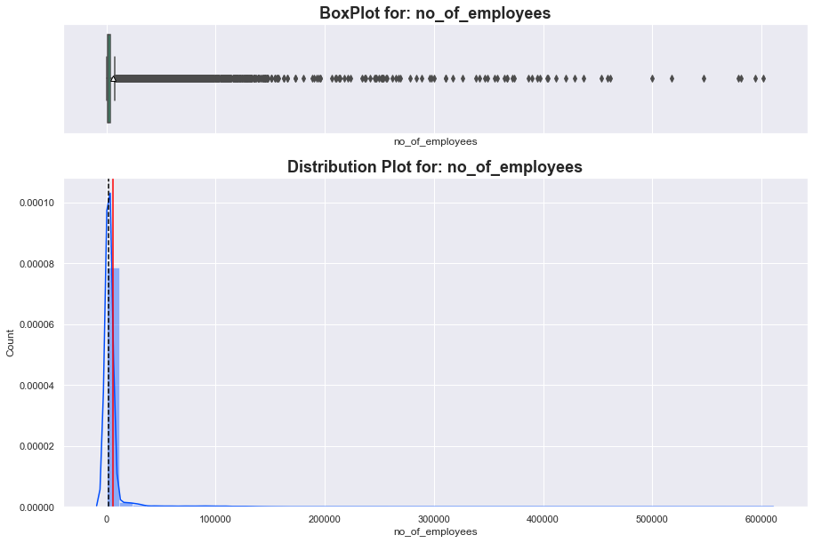

```python
box_hist(dfeasyvisa["no_of_employees"], "no_of_employees")
```

#### Observations:

- We can see there are no change in observations even after we have manipulated the variable

## Summary of EDA -

- `case_id` is just an unique identifier variable for each visa application, this will not have any significance while building predictive model for the solution hence it will be dropped when we prepare the data for modeling.
- `continent` variable has 6 unique continents from where the applicants belong, among these 6 continents we have observed Asia has the highest ~66.2% of applicants and Oceania has the lowest ~.8% of applicants. Despite Asia has the highest number of applicants Europe has the highest rate of visa approvals which is ~79% and Africa shows the second highest approval rate as ~72%
- `education_of_employee` this variable has the highest level of education of the applicant. Highest no of applicant's have completed their Bachelor's ~40.2% and ~37.8% have completed Masters. Applicants who have completed Doctorate which is very few only ~8.6% has the highest rate of visa approvals close to ~87%.
- `has_job_experience` from this variable we could observe ~58% of applicants have prior job experience and their visa approval rate is ~74.5%
- `requires_job_training` We have observed ~88% of applicants doesn't require any job training but we haven't observe any significance difference in approval rate between applicants who requires job training vs who doesn't.
- `no_of_employees` We have observed there are small to large scale employers in terms of their employee strength, we have observed there are employers with as high as 600000 employees, with average only ~5000 employees. We haven't observe any significant influnce on visa approvals.
- `yr_of_estab` We have seen establishment year of employers ranging from ~1800 - ~2016, however top 10 employers in terms of no of visa applicants are all established 1997 or after.
- `region_of_employment` There are 5 intented region of employment, among which Northeast has the highest number of applicants and Island os US has the lowest number of applicants. Midwest has the highest rate of approval ~76%
- `prevailing_wage` with varied range of prevailing wage we have observed for the cases which are approved has the higher average prevailing wage
- `unit_of_wage` There are 4 unique units present for prevailing wage and Yearly prevailing wage unit has the highest rate of approval ~70% and hourly wage shows the lowest approval rate ~35%
- `full_time_position` We don't see any specific relation with case approval rate based on if the position the applicant is applying for is full time or not
- `case_status` This is our dependent variable which we are trying to predict through modeling, dataset has ~66% of cases which are in certified status and ~34% cases which are denied.
- As from our EDA we can observe there are certain variables shows influence on the visa approval status, however we shall observe that after our model building and using feature importance based on what the predictive model shows.

## Data Prep for Model building

```python
# Taking backup before data prep for models
dfeasyvisa_b4_dataprepmodel = dfeasyvisa.copy()
```

```python
# Checking the dataset info
dfeasyvisa.info()
```

```
<class 'pandas.core.frame.DataFrame'>
RangeIndex: 25480 entries, 0 to 25479
Data columns (total 14 columns):
 #   Column                 Non-Null Count  Dtype
---  ------                 --------------  -----
 0   case_id                25480 non-null  category
 1   continent              25480 non-null  object
 2   education_of_employee  25480 non-null  object
 3   has_job_experience     25480 non-null  category
 4   requires_job_training  25480 non-null  category
 5   no_of_employees        25480 non-null  int64
 6   yr_of_estab            25480 non-null  int64
 7   region_of_employment   25480 non-null  category
 8   prevailing_wage        25480 non-null  float64
 9   unit_of_wage           25480 non-null  category
 10  full_time_position     25480 non-null  category
 11  case_status            25480 non-null  category
 12  employer_size          25480 non-null  object
 13  prevailing_wage_group  25480 non-null  object
dtypes: category(7), float64(1), int64(2), object(4)
memory usage: 2.8+ MB
```

### Converting the object type variables to category

```python
for col in dfeasyvisa.select_dtypes("object").columns:
    dfeasyvisa[col] = dfeasyvisa[col].astype("category")
dfeasyvisa.info()
```

```
<class 'pandas.core.frame.DataFrame'>
RangeIndex: 25480 entries, 0 to 25479
Data columns (total 14 columns):
 #   Column                 Non-Null Count  Dtype
---  ------                 --------------  -----
 0   case_id                25480 non-null  category
 1   continent              25480 non-null  category
 2   education_of_employee  25480 non-null  category
 3   has_job_experience     25480 non-null  category
 4   requires_job_training  25480 non-null  category
 5   no_of_employees        25480 non-null  int64
 6   yr_of_estab            25480 non-null  int64
 7   region_of_employment   25480 non-null  category
 8   prevailing_wage        25480 non-null  float64
 9   unit_of_wage           25480 non-null  category
 10  full_time_position     25480 non-null  category
 11  case_status            25480 non-null  category
 12  employer_size          25480 non-null  category
 13  prevailing_wage_group  25480 non-null  category
dtypes: category(11), float64(1), int64(2)
memory usage: 2.1 MB
```

- **All object variables are now converted to category**

### Dropping the case_id variable as it's just an unique identifier

```python
dfeasyvisa = dfeasyvisa.drop(["case_id"], axis=1)
dfeasyvisa.head()
```

|  | continent | education_of_employee | has_job_experience | requires_job_training | no_of_employees | yr_of_estab | region_of_employment | prevailing_wage | unit_of_wage | full_time_position | case_status | employer_size | prevailing_wage_group |
| --- | --- | --- | --- | --- | --- | --- | --- | --- | --- | --- | --- | --- | --- |
| 0 | Asia | HighSchool | N | N | 14513 | 2007 | West | 592.2029 | Hour | Y | Denied | VeryLarge | Low |
| 1 | Asia | Masters | Y | N | 2412 | 2002 | Northeast | 83425.6500 | Year | Y | Certified | Large | High |
| 2 | Asia | Bachelors | N | Y | 44444 | 2008 | West | 122996.8600 | Year | Y | Denied | VeryLarge | High |
| 3 | Asia | Bachelors | N | N | 98 | 1897 | West | 83434.0300 | Year | Y | Denied | Small | High |
| 4 | Africa | Masters | Y | N | 1082 | 2005 | South | 149907.3900 | Year | Y | Certified | Small | High |

### Converting the target variable to numeric class 1 and 0 - 1 for Certified and 0 for Denied

```python
dfeasyvisa["case_status"] = dfeasyvisa["case_status"].apply(
    lambda x: 1 if x == "Certified" else 0
)
dfeasyvisa
```

|  | continent | education_of_employee | has_job_experience | requires_job_training | no_of_employees | yr_of_estab | region_of_employment | prevailing_wage | unit_of_wage | full_time_position | case_status | employer_size | prevailing_wage_group |
| --- | --- | --- | --- | --- | --- | --- | --- | --- | --- | --- | --- | --- | --- |
| 0 | Asia | HighSchool | N | N | 14513 | 2007 | West | 592.2029 | Hour | Y | 0 | VeryLarge | Low |
| 1 | Asia | Masters | Y | N | 2412 | 2002 | Northeast | 83425.6500 | Year | Y | 1 | Large | High |
| 2 | Asia | Bachelors | N | Y | 44444 | 2008 | West | 122996.8600 | Year | Y | 0 | VeryLarge | High |
| 3 | Asia | Bachelors | N | N | 98 | 1897 | West | 83434.0300 | Year | Y | 0 | Small | High |
| 4 | Africa | Masters | Y | N | 1082 | 2005 | South | 149907.3900 | Year | Y | 1 | Small | High |
| ... | ... | ... | ... | ... | ... | ... | ... | ... | ... | ... | ... | ... | ... |
| 25475 | Asia | Bachelors | Y | Y | 2601 | 2008 | South | 77092.5700 | Year | Y | 1 | Large | High |
| 25476 | Asia | HighSchool | Y | N | 3274 | 2006 | Northeast | 279174.7900 | Year | Y | 1 | Large | High |
| 25477 | Asia | Masters | Y | N | 1121 | 1910 | South | 146298.8500 | Year | N | 1 | Medium | High |
| 25478 | Asia | Masters | Y | Y | 1918 | 1887 | West | 86154.7700 | Year | Y | 1 | Medium | High |
| 25479 | Asia | Bachelors | Y | N | 3195 | 1960 | Midwest | 70876.9100 | Year | Y | 1 | Large | Average |

25480 rows × 13 columns

```python
# Converting the dtype of case_status to int
dfeasyvisa["case_status"] = dfeasyvisa["case_status"].astype("int64")
dfeasyvisa.info()
```

```
<class 'pandas.core.frame.DataFrame'>
RangeIndex: 25480 entries, 0 to 25479
Data columns (total 13 columns):
 #   Column                 Non-Null Count  Dtype
---  ------                 --------------  -----
 0   continent              25480 non-null  category
 1   education_of_employee  25480 non-null  category
 2   has_job_experience     25480 non-null  category
 3   requires_job_training  25480 non-null  category
 4   no_of_employees        25480 non-null  int64
 5   yr_of_estab            25480 non-null  int64
 6   region_of_employment   25480 non-null  category
 7   prevailing_wage        25480 non-null  float64
 8   unit_of_wage           25480 non-null  category
 9   full_time_position     25480 non-null  category
 10  case_status            25480 non-null  int64
 11  employer_size          25480 non-null  category
 12  prevailing_wage_group  25480 non-null  category
dtypes: category(9), float64(1), int64(3)
memory usage: 1021.8 KB
```

### Let's quickly check on the data proportion in case_status and correlation matrix

### Data proportion in case_status

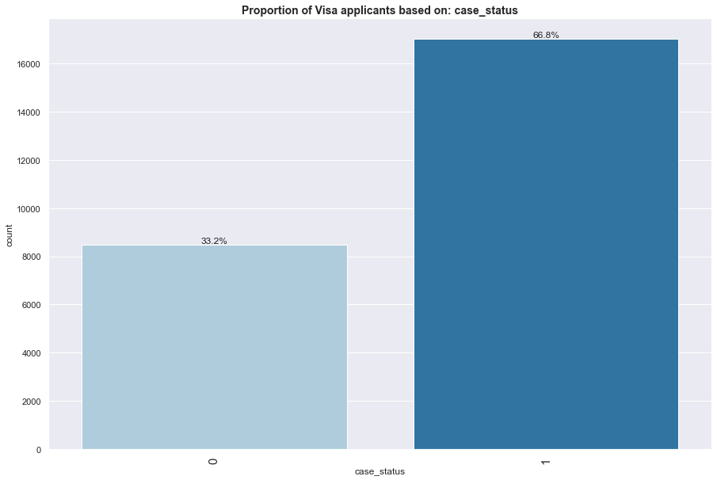

```python
labeled_barplot(dfeasyvisa, "case_status", perc=True)
```

#### Observations:

- We can observe that the data proportion remained same after convertion of case_status to numeric classes for modeling

### Checking the correlation matrix

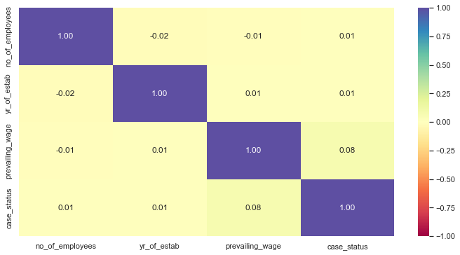

```python
plt.figure(figsize=(12, 6))
sns.heatmap(dfeasyvisa.corr(), annot=True, vmin=-1, vmax=1, fmt=".2f", cmap="Spectral")
plt.show()
```

#### Observations:

- We don't see any correlation between the numeric variables and with target variable

### Data Prep for model building contd...

### Dropping the yr_of_estab

```python
dfeasyvisa = dfeasyvisa.drop(["yr_of_estab"], axis=1)
dfeasyvisa.head()
```

|  | continent | education_of_employee | has_job_experience | requires_job_training | no_of_employees | region_of_employment | prevailing_wage | unit_of_wage | full_time_position | case_status | employer_size | prevailing_wage_group |
| --- | --- | --- | --- | --- | --- | --- | --- | --- | --- | --- | --- | --- |
| 0 | Asia | HighSchool | N | N | 14513 | West | 592.2029 | Hour | Y | 0 | VeryLarge | Low |
| 1 | Asia | Masters | Y | N | 2412 | Northeast | 83425.6500 | Year | Y | 1 | Large | High |
| 2 | Asia | Bachelors | N | Y | 44444 | West | 122996.8600 | Year | Y | 0 | VeryLarge | High |
| 3 | Asia | Bachelors | N | N | 98 | West | 83434.0300 | Year | Y | 0 | Small | High |
| 4 | Africa | Masters | Y | N | 1082 | South | 149907.3900 | Year | Y | 1 | Small | High |

### Create dummies with drop first as true

- All the categories columns need to be converted into numeric columns for modeling, we will use get_dummies method for the same

```python
dfeasyvisa = pd.get_dummies(dfeasyvisa, drop_first=True)
dfeasyvisa
```

|  | no_of_employees | prevailing_wage | case_status | continent_Asia | continent_Europe | continent_NorthAmerica | continent_Oceania | continent_SouthAmerica | education_of_employee_Doctorate | education_of_employee_HighSchool | ... | region_of_employment_West | unit_of_wage_Month | unit_of_wage_Week | unit_of_wage_Year | full_time_position_Y | employer_size_Medium | employer_size_Small | employer_size_VeryLarge | prevailing_wage_group_High | prevailing_wage_group_Low |
| --- | --- | --- | --- | --- | --- | --- | --- | --- | --- | --- | --- | --- | --- | --- | --- | --- | --- | --- | --- | --- | --- |
| 0 | 14513 | 592.2029 | 0 | 1 | 0 | 0 | 0 | 0 | 0 | 1 | ... | 1 | 0 | 0 | 0 | 1 | 0 | 0 | 1 | 0 | 1 |
| 1 | 2412 | 83425.6500 | 1 | 1 | 0 | 0 | 0 | 0 | 0 | 0 | ... | 0 | 0 | 0 | 1 | 1 | 0 | 0 | 0 | 1 | 0 |
| 2 | 44444 | 122996.8600 | 0 | 1 | 0 | 0 | 0 | 0 | 0 | 0 | ... | 1 | 0 | 0 | 1 | 1 | 0 | 0 | 1 | 1 | 0 |
| 3 | 98 | 83434.0300 | 0 | 1 | 0 | 0 | 0 | 0 | 0 | 0 | ... | 1 | 0 | 0 | 1 | 1 | 0 | 1 | 0 | 1 | 0 |
| 4 | 1082 | 149907.3900 | 1 | 0 | 0 | 0 | 0 | 0 | 0 | 0 | ... | 0 | 0 | 0 | 1 | 1 | 0 | 1 | 0 | 1 | 0 |
| ... | ... | ... | ... | ... | ... | ... | ... | ... | ... | ... | ... | ... | ... | ... | ... | ... | ... | ... | ... | ... | ... |
| 25475 | 2601 | 77092.5700 | 1 | 1 | 0 | 0 | 0 | 0 | 0 | 0 | ... | 0 | 0 | 0 | 1 | 1 | 0 | 0 | 0 | 1 | 0 |
| 25476 | 3274 | 279174.7900 | 1 | 1 | 0 | 0 | 0 | 0 | 0 | 1 | ... | 0 | 0 | 0 | 1 | 1 | 0 | 0 | 0 | 1 | 0 |
| 25477 | 1121 | 146298.8500 | 1 | 1 | 0 | 0 | 0 | 0 | 0 | 0 | ... | 0 | 0 | 0 | 1 | 0 | 1 | 0 | 0 | 1 | 0 |
| 25478 | 1918 | 86154.7700 | 1 | 1 | 0 | 0 | 0 | 0 | 0 | 0 | ... | 1 | 0 | 0 | 1 | 1 | 1 | 0 | 0 | 1 | 0 |
| 25479 | 3195 | 70876.9100 | 1 | 1 | 0 | 0 | 0 | 0 | 0 | 0 | ... | 0 | 0 | 0 | 1 | 1 | 0 | 0 | 0 | 0 | 0 |

25480 rows × 26 columns

- **All the category variables are now converted into dummies with 1 and 0**

### Now create the X (independent variables) and y (dependent variable) for model

```python
# Take backup before creating X and y for model
dfeasyvisa_b4_modelprep = dfeasyvisa.copy()
```

```python
X = dfeasyvisa.drop(["case_status"], axis=1)
y = dfeasyvisa["case_status"]
print("Shape of X", X.shape)
print("Shape of y", y.shape)
```

```
Shape of X (25480, 25)
Shape of y (25480,)
```

### Split the dataset into train and test in 70:30 ratio

```python
# Splitting data into training and test set:
X_train, X_test, y_train, y_test = train_test_split(
    X, y, test_size=0.3, random_state=1, stratify=y
)
print(X_train.shape, X_test.shape)
```

```
(17836, 25) (7644, 25)
```

```python
print(y_train.value_counts() / y_train.count())
```

```
1    0.667919
0    0.332081
Name: case_status, dtype: float64
```

```python
print(y_test.value_counts() / y_test.count())
```

```
1    0.667844
0    0.332156
Name: case_status, dtype: float64
```

#### Observations:

- We have split our dataset into X and y train and test set respectively.
- X train has 17836 observations, we will train our model on these observations.
- X test has 7644 observations and we will be testing performance of our model on these observations.
- y train and test we can see we are able to maintain the proportion of case status (dependent variable) same as the original dataset

## Model Building

- Before we build our model, let's set the model evaluation criteria first, based on which we will evaluate the performance of all the models we will build and decide which model best fit the business purpose.

### Model evaluation criterion

#### The model can make wrong predictions as:

1. Predicting an applicant's visa would be certified but in actual it will be denied.
2. Predicting an applicant's visa would be denied but in actual it will be certified.

#### Which case is more important?

1. If the model predicts an applicant's visa would be certified but in actual it will be denied, company will have loss of time and resources.
2. If the model predicts an applicant's visa would be denied but in actual it will be certified, company will also have loss of time and resources.
- For both scenario the wrong prediction will incurr additional manual evaluation hence loss of time and resources and the ML solution will not help speed up the process.

#### Which metric to optimize?

- We would want F1-Score to be maximized, the greater the F1-Score higher the chances of predicting both the classes correctly.
- However, OFLC is also looking for possible applicants who are more likely to be granted visa, hence recall is also an important parameter which we will take into consideration

**Let's define a function to provide metric scores on the train and test set and a function to show confusion matrix so that we do not have to use the same code repetitively while evaluating models.**

```python
# defining a function to compute different metrics to check performance of a classification model built using sklearn
def model_performance_classification_sklearn(model, predictors, target):
    """
    Function to compute different metrics to check classification model performance

    model: classifier
    predictors: independent variables
    target: dependent variable
    """

    # predicting using the independent variables
    pred = model.predict(predictors)

    acc = accuracy_score(target, pred)  # to compute Accuracy
    recall = recall_score(target, pred)  # to compute Recall
    precision = precision_score(target, pred)  # to compute Precision
    f1 = f1_score(target, pred)  # to compute F1-score

    # creating a dataframe of metrics
    df_perf = pd.DataFrame(
        {"Accuracy": acc, "Recall": recall, "Precision": precision, "F1": f1,},
        index=[0],
    )

    return df_perf
```

```python
def confusion_matrix_sklearn(model, predictors, target):
    """
    To plot the confusion_matrix with percentages

    model: classifier
    predictors: independent variables
    target: dependent variable
    """
    y_pred = model.predict(predictors)
    cm = confusion_matrix(target, y_pred)
    labels = np.asarray(
        [
            ["{0:0.0f}".format(item) + "\n{0:.2%}".format(item / cm.flatten().sum())]
            for item in cm.flatten()
        ]
    ).reshape(2, 2)

    plt.figure(figsize=(6, 4))
    sns.heatmap(cm, annot=labels, fmt="")
    plt.ylabel("True label")
    plt.xlabel("Predicted label")
```

#### Let's create another function to plot feature importances for models

```python
def model_feature_importances(model, features):
    feature_names = features.columns
    importances = model.feature_importances_
    indices = np.argsort(importances)

    plt.figure(figsize=(12, 12))
    plt.title("Feature Importances")
    plt.barh(
        range(len(indices)), importances[indices], color="lightgreen", align="center"
    )
    plt.yticks(range(len(indices)), [feature_names[i] for i in indices])
    plt.xlabel("Relative Importance")
    plt.show()
```

## Building - Decision Tree Classifier

#### Fitting the decision tree with default parameters

```python
# Fitting the model
d_tree = DecisionTreeClassifier(random_state=1)
d_tree.fit(X_train, y_train)
```

```
DecisionTreeClassifier(random_state=1)
```

#### Checking the training performance

```
Training performance:
    Accuracy  Recall  Precision   F1
0       1.0     1.0        1.0  1.0
```

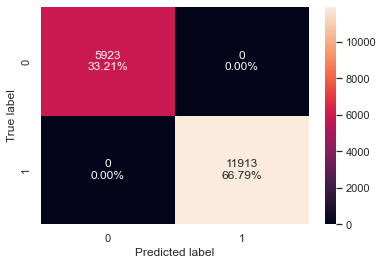

```python
# Calculating different metrics
d_tree_model_train_perf = model_performance_classification_sklearn(
    d_tree, X_train, y_train
)
print("Training performance:\n", d_tree_model_train_perf)
# Creating confusion matrix
confusion_matrix_sklearn(d_tree, X_train, y_train)
```

#### Checking the testing performance

```
Testing performance:
    Accuracy    Recall  Precision        F1
0  0.645997  0.734574    0.73515  0.734862
```

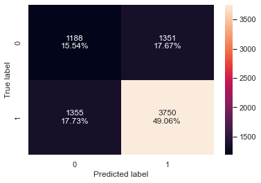

```python
# Calculating different metrics
d_tree_model_test_perf = model_performance_classification_sklearn(
    d_tree, X_test, y_test
)
print("Testing performance:\n", d_tree_model_test_perf)
# Creating confusion matrix
confusion_matrix_sklearn(d_tree, X_test, y_test)
```

#### Observations:

- Default decision tree overfitted on the training data, f1 score shows 100%.
- On test data f1 score is ~73% compared to training 100%, this confirms this model is overfitted.
- We will try to tune the model using hyper parameter and see if the model performance improves and if we can reduce the overfitting.